# Facebook Dataset Analysis Final Project

Jianye Han, Zach Litz, Megan Masanz

July 25, 2017

### Methods

#### Variable Exploration

##### 1. Variable Exploration Additive Model

Below is reading in the dataset as a table given there are spaces in the variable names. In addition the variables that are required to be set as factors are set to factors here.

```r
fb = read.table("dataset_Facebook.csv", sep = ";", header = T)

fb$Type           = as.factor(fb$Type)
fb$Category       = as.factor(fb$Category)
fb$Post.Month     = as.factor(fb$Post.Month)
fb$Post.Hour      = as.factor(fb$Post.Hour)
fb$Post.Weekday   = as.factor(fb$Post.Weekday)
fb$Paid           = as.factor(fb$Paid)
```

Initial full additive model.

```r
full_model = lm(Lifetime.Post.Consumers ~ ., data = fb)
variables = colnames(fb)
```

The variables to analyze can be found below

#### 1.1 Table of predictor variables

```r
knitr::kable(colnames(fb), caption = "Variables for Analysis")
```

Variables for Analysis

| Page.total.likes |
| --- |
| Type |
| Category |
| Post.Month |
| Post.Weekday |
| Post.Hour |
| Paid |
| Lifetime.Post.Total.Reach |
| Lifetime.Post.Total.Impressions |
| Lifetime.Engaged.Users |
| Lifetime.Post.Consumers |
| Lifetime.Post.Consumptions |
| Lifetime.Post.Impressions.by.people.who.have.liked.your.Page |
| Lifetime.Post.reach.by.people.who.like.your.Page |
| Lifetime.People.who.have.liked.your.Page.and.engaged.with.your.post |
| comment |
| like |
| share |
| Total.Interactions |

```r
#Perfect correlation so removed
fb$Total.Interactions = NULL
full_model = lm(Lifetime.Post.Consumers ~ ., data = fb)
```

```r
#number of rows
nrow(fb)
```

```
## [1] 500
```

```r
#Cleansing Data
fb = fb[complete.cases(fb), ]
nrow(fb)
```

```
## [1] 495
```

```r
#Initial Analysis:
variables = colnames(fb)
predictor_variables = variables[which(variables != "Lifetime.Post.Consumers")]
response_variable = "Lifetime.Post.Consumers"
```

First we will look at the $R{j}^2$ for each of the predictor variables. Recall the $R{j}^2$ is the proportion of observed variation in the j-th predictor explained by the other predictors.

```r
get_RjSquared = function(predictor_variables){
  rj_squared = rep(0, length(predictor_variables))
  for (i in 1: length(predictor_variables))
  {
    strModel     = paste(predictor_variables[i], "~ . - Lifetime.Post.Consumers")
    temp_model   = lm(strModel, data = fb)
    rj_squared[i] = summary(temp_model)$r.squared
  }
  data.frame(predictor_variables = predictor_variables, rj_squared = rj_squared )
}

RjsquaredForPredictors = get_RjSquared(predictor_variables)
```

#### 1.1.2 Table of predictor variables

```r
knitr::kable(RjsquaredForPredictors, caption = "Rj^2")
```

Rj^2

| predictor_variables | rj_squared |
| --- | --- |
| Page.total.likes | 0.9935323 |
| Type | NA |
| Category | NA |
| Post.Month | NA |
| Post.Weekday | NA |
| Post.Hour | NA |
| Paid | NA |
| Lifetime.Post.Total.Reach | 0.9586174 |
| Lifetime.Post.Total.Impressions | 0.9717510 |
| Lifetime.Engaged.Users | 0.8930983 |
| Lifetime.Post.Consumptions | 0.6127660 |
| Lifetime.Post.Impressions.by.people.who.have.liked.your.Page | 0.9597066 |
| Lifetime.Post.reach.by.people.who.like.your.Page | 0.9140879 |
| Lifetime.People.who.have.liked.your.Page.and.engaged.with.your.post | 0.8945225 |
| comment | 0.8100827 |
| like | 0.9102457 |
| share | 0.8953746 |

This information suggests that we will have high VIF values for our predictors.

```r
vif(full_model)
```

```
##                                                    Page.total.likes
##                                                          154.613421
##                                                           TypePhoto
##                                                            3.682906
##                                                          TypeStatus
##                                                            5.098167
##                                                           TypeVideo
##                                                            1.566172
##                                                           Category2
##                                                            2.160362
##                                                           Category3
##                                                            1.996792
##                                                         Post.Month2
##                                                            3.861434
##                                                         Post.Month3
##                                                           11.489244
##                                                         Post.Month4
##                                                           35.218434
##                                                         Post.Month5
##                                                           44.660050
##                                                         Post.Month6
##                                                           84.777026
##                                                         Post.Month7
##                                                          110.662951
##                                                         Post.Month8
##                                                           85.590003
##                                                         Post.Month9
##                                                           97.154123
##                                                        Post.Month10
##                                                          158.416314
##                                                        Post.Month11
##                                                          135.093850
##                                                        Post.Month12
##                                                          155.379927
##                                                       Post.Weekday2
##                                                            1.942709
##                                                       Post.Weekday3
##                                                            1.919429
##                                                       Post.Weekday4
##                                                            1.961561
```

[output cut: 55 more lines]

```
##                                                            9.354385
##                                          Lifetime.Post.Consumptions
##                                                            2.582418
##        Lifetime.Post.Impressions.by.people.who.have.liked.your.Page
##                                                           24.817942
##                    Lifetime.Post.reach.by.people.who.like.your.Page
##                                                           11.639808
## Lifetime.People.who.have.liked.your.Page.and.engaged.with.your.post
##                                                            9.480699
##                                                             comment
##                                                            5.265450
##                                                                like
##                                                           11.141526
##                                                               share
##                                                            9.557913
```

Using the variance inflaction factor to quantify the impact of collinearity on the variance of the regression estimates, we know that this will be a bad model for explaining the relationship between the response and predictors requiring the model to be simplied

Given the large number of predictors, we will begin with attempting to understand which predictor variables should be explored. The function `getAdditiveModels` will git a model starting with 1 $\beta$ parameter for each of the parameters that were found in 1.1 Table of predictor variables. For a given $\beta$ parameter, the model fit with the lowest RSS will then be used to fit the next size of $\beta$ parameters.

The function `getModels` will retrieve for every number of $\beta$ parameters the model with the lowest RSS.

the function `doAnova` finally will do an Anova F-Test to determine which is the preferred model, comparing model with $\beta$ parmaters of size `i` to that of `i+1`. Once the Anova F-Test values **fail** to produce a better model, the function stops determining the best MLR additive model has been determined.

```r
getAdditiveModels = function(variables, response_variable, data_set, alpha)
{
  num_predictor_variables = length(variables)
  p_val           = rep(0, num_predictor_variables ^ 2)
  bp_p_value      = rep(0, num_predictor_variables ^ 2)
  shapiro_p_value = rep(0, num_predictor_variables ^ 2)
  strmodel        = rep(0, num_predictor_variables ^ 2)
  rss             = rep(0, num_predictor_variables ^ 2)
  beta_parameter  = rep(0, num_predictor_variables ^ 2)
  pass_bp         = rep(0, num_predictor_variables ^ 2)
  pass_shapiro    = rep(0, num_predictor_variables ^ 2)
  adjustedR2      = rep(0, num_predictor_variables ^ 2)
  sizeResiduals   = rep(0, num_predictor_variables ^ 2)

  index = 1;

  for (j in 1:num_predictor_variables)
  {
    smallestrss = 0
    smallestrssIndex = 0
    for (i in 1:length(variables))
    {
      if(j == 1) #at the beginning
      {
        startpointer          = index
        #could make s1 be log(y)
        s1                    = response_variable
        s2                    = variables[i]
        strmodel[index]       = paste(s1, " ~ " , s2)
      }
      else
      {
        s2                    = variables[i]
        strmodel[index]       = paste(previousBestModel , " + " , s2)
      }

      model                    = lm(strmodel[index], data = data_set)
      rss[index]               = sum(resid(model)^2)
      bp_p_value[index]        = bptest(model)$p.value
      shapiro_p_value[index]   = shapiro.test(resid(model))$p.value
      beta_parameter[index]    = j
      adjustedR2[index]        = summary(model)$adj.r.squared
      sizeResiduals[index]     = length(resid(model))

      if (shapiro_p_value[i] > alpha) {
        pass_shapiro[index] = TRUE
      }

      if (bp_p_value[i] > alpha) {
        pass_bp[index] = TRUE
      }

      if (smallestrssIndex == 0 || rss[index] < smallestrss){
        smallestrssIndex = index
        smallestrss = rss[index]
      }
      index = index + 1
    }
    #for a given number of predictor variables create temp vector and find the min rss
    previousBestModel = strmodel[smallestrssIndex]
  }
  result         = data.frame(beta_parameter, strmodel, rss, adjustedR2,
                              bp_p_value, shapiro_p_value, pass_bp, pass_shapiro, sizeResiduals)
  result$strmodel =  as.character(result$strmodel)
  result
}



#here is a function that for a given number of beta parameters pulls out the lowest rss
getModels = function(results, num_predictor_variables){
  bestModelForParamNumber = rep("", num_predictor_variables)
  for (i in 1:num_predictor_variables)
  {
    subset_data = results[results$beta_parameter == i, ]
    bestModelForParamNumber[i] = subset_data$strmodel[which.min(subset_data$rss)]
  }
  bestModelForParamNumber
}



#now for each of the "best" linear models, do an anova test to determine which are actually the best
doAnova = function(dataset, models, alpha)
{
  p_val         = rep(0, length(models) - 1)
  keep_old      = rep(FALSE, length(models) - 1)
  winning_model = rep(0, length(models) - 1)
  stop = FALSE
  for (i in 1:(length(models) -1))
  {
    if (stop == FALSE)
    {
      p_val[i] = anova(lm(bestModels[i], data = dataset), lm(bestModels[i + 1], data = dataset))$"Pr(>F)"[2]
      if (p_val[i] < alpha)
      {
        keep_old[i]      = FALSE
        winning_model[i] = bestModels[i + 1]
        stop             = FALSE
      }
      else
      {
        keep_old[i]      = TRUE
        winning_model[i] = bestModels[i]
        report_winning   = winning_model[1:i]
        report_p_val     = p_val[1:i]
        report_keep_old  = keep_old[1:i]
        stop             = TRUE
        i                = length(models) -1
      }
    }
  }

  output                = data.frame(report_winning, report_p_val, report_keep_old)
  output$report_winning =  as.character(output$report_winning)
  output
}

results = getAdditiveModels(predictor_variables, response_variable, fb, .05)
bestModels = getModels(results, length(predictor_variables))
results = doAnova(fb, bestModels, 0.05 )
model_data_selected_RSS_Manual = results[results$report_keep_old == TRUE, ]
model_selected_RSS_Manual      = lm(model_data_selected_RSS_Manual$report_winning, data = fb)

#Model from Manual Selection
model_data_selected_RSS_Manual$report_winning
```

```
## [1] "Lifetime.Post.Consumers  ~  Lifetime.Engaged.Users  +  like  +  share  +  Lifetime.People.who.have.liked.your.Page.and.engaged.with.your.post  +  Post.Month  +  Lifetime.Post.Consumptions  +  comment  +  Lifetime.Post.Total.Reach"
```

```r
#best additive model based on RSS and Anova Test
#Lifetime.Post.Consumers  ~  Lifetime.Engaged.Users  +  like  +  share  +  Lifetime.People.who.have.liked.your.Page.and.engaged.with.your.post  +  Post.Month  +  Lifetime.Post.Consumptions  +  comment  +  Lifetime.Post.Total.Reach
```

```r
vif(model_selected_RSS_Manual)
```

```
##                                              Lifetime.Engaged.Users
##                                                            6.104291
##                                                                like
##                                                            7.240785
##                                                               share
##                                                            7.874167
## Lifetime.People.who.have.liked.your.Page.and.engaged.with.your.post
##                                                            3.829452
##                                                         Post.Month2
##                                                            1.990061
##                                                         Post.Month3
##                                                            2.441669
##                                                         Post.Month4
##                                                            2.873595
##                                                         Post.Month5
##                                                            2.427960
##                                                         Post.Month6
##                                                            2.865803
##                                                         Post.Month7
##                                                            2.937524
##                                                         Post.Month8
##                                                            2.388154
##                                                         Post.Month9
##                                                            2.375506
##                                                        Post.Month10
##                                                            3.124805
##                                                        Post.Month11
##                                                            2.711150
##                                                        Post.Month12
##                                                            2.915455
##                                          Lifetime.Post.Consumptions
##                                                            2.138723
##                                                             comment
##                                                            4.561069
##                                           Lifetime.Post.Total.Reach
##                                                            1.834130
```

The variance inflation factors for this model are much improved from the model including all predictors, however we still see values greater than 5. Given we are looking for a model to explain, we will continue with evaluation of model selection using backwards and forwards BIC and AIC to determine if a simplier additive model can be achieved before attempting to find a simple model for explaining the response variable.

At this point, we will remove the cateogical variables from the analysis and evaluate adding them back in after simplifying the model down to reduce complexity of our evaluation. Using R to create models using AIC and BIC (forwards and backwards) R will automatically create dummy variables for us, but that will introduce many variables and at this point in the analylsis we will prevent that by excluding these variables from the analysis at this stage. Note the the manual RSS selection process did indicate the `Post.Month` was significant when we assumed an $\alpha$ = 0.05.

Due to this descision, we will again run the code above but excluding the categorical variable to assist in model comparision process.

```r
variables
```

```
##  [1] "Page.total.likes"
##  [2] "Type"
##  [3] "Category"
##  [4] "Post.Month"
##  [5] "Post.Weekday"
##  [6] "Post.Hour"
##  [7] "Paid"
##  [8] "Lifetime.Post.Total.Reach"
##  [9] "Lifetime.Post.Total.Impressions"
## [10] "Lifetime.Engaged.Users"
## [11] "Lifetime.Post.Consumers"
## [12] "Lifetime.Post.Consumptions"
## [13] "Lifetime.Post.Impressions.by.people.who.have.liked.your.Page"
## [14] "Lifetime.Post.reach.by.people.who.like.your.Page"
## [15] "Lifetime.People.who.have.liked.your.Page.and.engaged.with.your.post"
## [16] "comment"
## [17] "like"
## [18] "share"
```

```r
predictor_variables = variables[which(variables != "Lifetime.Post.Consumers"
                                      & variables != "Type" & variables != "Category" & variables != "Post.Month"
                                      & variables != "Post.Weekday"
                                      & variables != "Post.Hour" & variables != "Paid" )]

#Variables for analysis
predictor_variables
```

```
##  [1] "Page.total.likes"
##  [2] "Lifetime.Post.Total.Reach"
##  [3] "Lifetime.Post.Total.Impressions"
##  [4] "Lifetime.Engaged.Users"
##  [5] "Lifetime.Post.Consumptions"
##  [6] "Lifetime.Post.Impressions.by.people.who.have.liked.your.Page"
##  [7] "Lifetime.Post.reach.by.people.who.like.your.Page"
##  [8] "Lifetime.People.who.have.liked.your.Page.and.engaged.with.your.post"
##  [9] "comment"
## [10] "like"
## [11] "share"
```

```r
results = getAdditiveModels(predictor_variables, response_variable, fb, .05)
bestModels = getModels(results, length(predictor_variables))
results = doAnova(fb, bestModels, 0.05 )
model_data_selected_RSS_Manual = results[results$report_keep_old == TRUE, ]
model_selected_RSS_Manual      = lm(model_data_selected_RSS_Manual$report_winning, data = fb)

#Model from Manual Selection
model_data_selected_RSS_Manual$report_winning
```

```
## [1] "Lifetime.Post.Consumers  ~  Lifetime.Engaged.Users  +  like  +  share  +  Lifetime.People.who.have.liked.your.Page.and.engaged.with.your.post  +  Lifetime.Post.Consumptions  +  comment  +  Page.total.likes  +  Lifetime.Post.Total.Reach  +  Lifetime.Post.Total.Impressions"
```

The function `createStringFullModel` is simply used to create model given the large number of predictor variables. The string will be used in the AIC methods.

```r
###########################################################
#AIC and BIC
##########################################################



createStringFullModel = function(predictor_variables){
  num_predictor_variables = length(predictor_variables)
  for (i in 1:num_predictor_variables)
  {
    if (i == 1)
    {
      model = paste("Lifetime.Post.Consumers", "~" ,predictor_variables[i] )
    }
    else
      model = paste(model , " + " , predictor_variables[i])
  }
  model
}

strFullModel = createStringFullModel(predictor_variables)


##########################################################
#AIC - less aggressive
##########################################################
#forward AIC
fb_mod_start = lm(Lifetime.Post.Consumers ~ 1, data = fb)
model_forward_aic = step(fb_mod_start,
                         strFullModel,
                         direction = "forward", trace = 0)
```

```r
summary(model_forward_aic)
```

```
##
## Call:
## lm(formula = Lifetime.Post.Consumers ~ Lifetime.Engaged.Users +
##     like + share + Lifetime.People.who.have.liked.your.Page.and.engaged.with.your.post +
##     Lifetime.Post.Consumptions + comment + Page.total.likes +
##     Lifetime.Post.Total.Reach + Lifetime.Post.Total.Impressions +
##     Lifetime.Post.Impressions.by.people.who.have.liked.your.Page,
##     data = fb)
##
## Residuals:
##      Min       1Q   Median       3Q      Max
## -171.146  -10.623   -1.326    8.910  313.186
##
## Coefficients:
##                                                                       Estimate
## (Intercept)                                                          4.412e+01
## Lifetime.Engaged.Users                                               9.967e-01
## like                                                                -9.240e-01
## share                                                                8.337e-01
## Lifetime.People.who.have.liked.your.Page.and.engaged.with.your.post  3.033e-02
## Lifetime.Post.Consumptions                                           5.509e-03
## comment                                                              5.450e-01
## Page.total.likes                                                    -3.684e-04
## Lifetime.Post.Total.Reach                                           -6.488e-04
## Lifetime.Post.Total.Impressions                                      1.623e-04
## Lifetime.Post.Impressions.by.people.who.have.liked.your.Page        -1.130e-04
##                                                                     Std. Error
## (Intercept)                                                          1.200e+01
## Lifetime.Engaged.Users                                               3.616e-03
## like                                                                 1.246e-02
## share                                                                9.407e-02
## Lifetime.People.who.have.liked.your.Page.and.engaged.with.your.post  4.627e-03
## Lifetime.Post.Consumptions                                           1.017e-03
## comment                                                              1.438e-01
## Page.total.likes                                                     9.449e-05
## Lifetime.Post.Total.Reach                                            1.711e-04
## Lifetime.Post.Total.Impressions                                      7.630e-05
## Lifetime.Post.Impressions.by.people.who.have.liked.your.Page         7.549e-05
##                                                                     t value
## (Intercept)                                                           3.678
```

[output cut: 25 more lines]

```
## like                                                                ***
## share                                                               ***
## Lifetime.People.who.have.liked.your.Page.and.engaged.with.your.post ***
## Lifetime.Post.Consumptions                                          ***
## comment                                                             ***
## Page.total.likes                                                    ***
## Lifetime.Post.Total.Reach                                           ***
## Lifetime.Post.Total.Impressions                                     *
## Lifetime.Post.Impressions.by.people.who.have.liked.your.Page
## ---
## Signif. codes:  0 '***' 0.001 '**' 0.01 '*' 0.05 '.' 0.1 ' ' 1
##
## Residual standard error: 31.75 on 484 degrees of freedom
## Multiple R-squared:  0.9987, Adjusted R-squared:  0.9987
## F-statistic: 3.835e+04 on 10 and 484 DF,  p-value: < 2.2e-16
```

```r
vif(model_forward_aic)
```

```
##                                              Lifetime.Engaged.Users
##                                                            6.252803
##                                                                like
##                                                            8.009384
##                                                               share
##                                                            7.890644
## Lifetime.People.who.have.liked.your.Page.and.engaged.with.your.post
##                                                            3.960603
##                                          Lifetime.Post.Consumptions
##                                                            2.041967
##                                                             comment
##                                                            4.587711
##                                                    Page.total.likes
##                                                            1.148765
##                                           Lifetime.Post.Total.Reach
##                                                            7.471102
##                                     Lifetime.Post.Total.Impressions
##                                                           16.977240
##        Lifetime.Post.Impressions.by.people.who.have.liked.your.Page
##                                                           10.079267
```

```r
vif(model_selected_RSS_Manual)
```

```
##                                              Lifetime.Engaged.Users
##                                                            6.198262
##                                                                like
##                                                            7.038711
##                                                               share
##                                                            7.520484
## Lifetime.People.who.have.liked.your.Page.and.engaged.with.your.post
##                                                            3.909089
##                                          Lifetime.Post.Consumptions
##                                                            2.037193
##                                                             comment
##                                                            4.586158
##                                                    Page.total.likes
##                                                            1.131435
##                                           Lifetime.Post.Total.Reach
##                                                            3.005142
##                                     Lifetime.Post.Total.Impressions
##                                                            2.083377
```

These 2 methods appear to select very similiar models, with the exception of forward AIC chosing an additional parameter `Lifetime.Post.Impressions.by.people.who.have.liked.your.Page` which does appear to have increased the VIF significantly, so we would probably choose to reject adding this variable to our model.

#### 1.1.2 Variables Added Plot comparing RSS manually selected model with the addition suggested by forward AIC

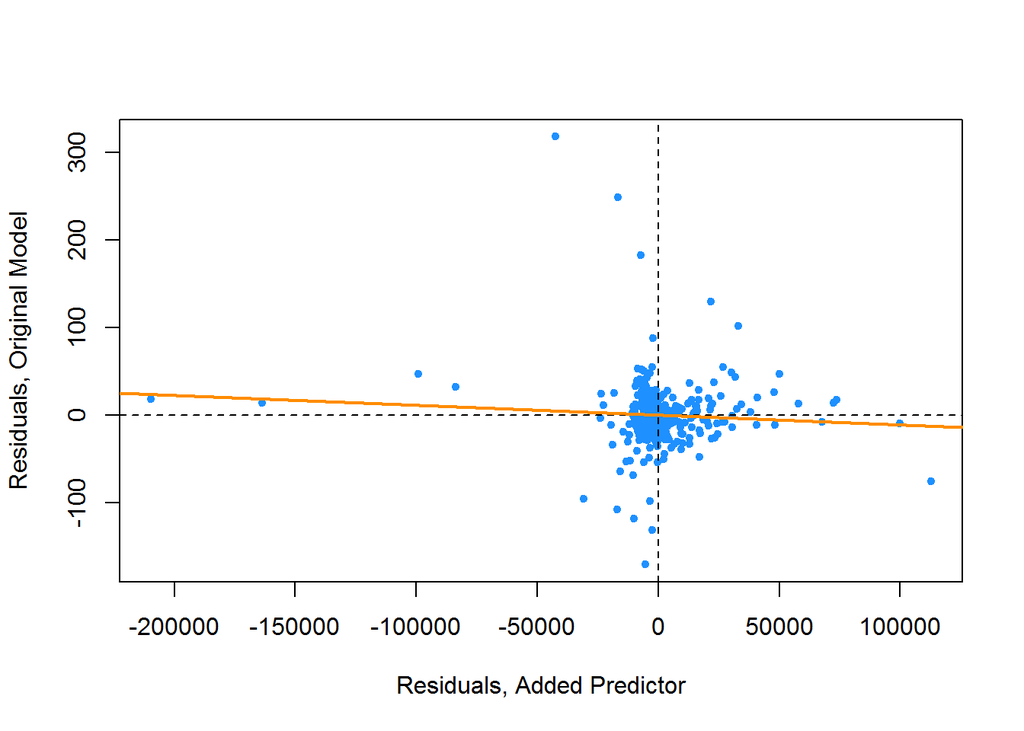

```r
#variable added plot
ImpressionsModel = lm(Lifetime.Post.Impressions.by.people.who.have.liked.your.Page ~
                        Lifetime.Engaged.Users + like + share +
                        Lifetime.People.who.have.liked.your.Page.and.engaged.with.your.post +
                        Lifetime.Post.Consumptions +
                        comment + Page.total.likes +
                        Lifetime.Post.Total.Reach +
                        Lifetime.Post.Total.Impressions, data  = fb)

plot(resid(model_selected_RSS_Manual) ~ resid(ImpressionsModel), col = "dodgerblue", pch = 20,
     xlab = "Residuals, Added Predictor", ylab = "Residuals, Original Model")
abline(h = 0, lty = 2)
abline(v = 0, lty = 2)
abline(lm(resid(model_selected_RSS_Manual) ~ resid(ImpressionsModel)),
       col = "darkorange", lwd = 2)
```

The partial correlation coefficient of `Lifetime.Post.Impressions.by.people.who.have.liked.your.Page` and `Lifetime.Post.Consumers` with the effects of the other variables in the model removed serves as additional justication that this predictors should not end up in our final selected model.

```r
cor(resid(ImpressionsModel), resid(model_selected_RSS_Manual))
```

```
## [1] -0.06790197
```

Next we examine backwards AIC

```r
fullModel = lm(strFullModel, data = fb)
model_back_aic = step(fullModel, direction = "backward", trace = 0)
summary(model_back_aic)
```

```
##
## Call:
## lm(formula = Lifetime.Post.Consumers ~ Page.total.likes + Lifetime.Post.Total.Reach +
##     Lifetime.Post.Total.Impressions + Lifetime.Engaged.Users +
##     Lifetime.Post.Consumptions + Lifetime.Post.Impressions.by.people.who.have.liked.your.Page +
##     Lifetime.People.who.have.liked.your.Page.and.engaged.with.your.post +
##     comment + like + share, data = fb)
##
## Residuals:
##      Min       1Q   Median       3Q      Max
## -171.146  -10.623   -1.326    8.910  313.186
##
## Coefficients:
##                                                                       Estimate
## (Intercept)                                                          4.412e+01
## Page.total.likes                                                    -3.684e-04
## Lifetime.Post.Total.Reach                                           -6.488e-04
## Lifetime.Post.Total.Impressions                                      1.623e-04
## Lifetime.Engaged.Users                                               9.967e-01
## Lifetime.Post.Consumptions                                           5.509e-03
## Lifetime.Post.Impressions.by.people.who.have.liked.your.Page        -1.130e-04
## Lifetime.People.who.have.liked.your.Page.and.engaged.with.your.post  3.033e-02
## comment                                                              5.450e-01
## like                                                                -9.240e-01
## share                                                                8.337e-01
##                                                                     Std. Error
## (Intercept)                                                          1.200e+01
## Page.total.likes                                                     9.449e-05
## Lifetime.Post.Total.Reach                                            1.711e-04
## Lifetime.Post.Total.Impressions                                      7.630e-05
## Lifetime.Engaged.Users                                               3.616e-03
## Lifetime.Post.Consumptions                                           1.017e-03
## Lifetime.Post.Impressions.by.people.who.have.liked.your.Page         7.549e-05
## Lifetime.People.who.have.liked.your.Page.and.engaged.with.your.post  4.627e-03
## comment                                                              1.438e-01
## like                                                                 1.246e-02
## share                                                                9.407e-02
##                                                                     t value
## (Intercept)                                                           3.678
## Page.total.likes                                                     -3.899
```

[output cut: 24 more lines]

```
## Lifetime.Post.Total.Reach                                           ***
## Lifetime.Post.Total.Impressions                                     *
## Lifetime.Engaged.Users                                              ***
## Lifetime.Post.Consumptions                                          ***
## Lifetime.Post.Impressions.by.people.who.have.liked.your.Page
## Lifetime.People.who.have.liked.your.Page.and.engaged.with.your.post ***
## comment                                                             ***
## like                                                                ***
## share                                                               ***
## ---
## Signif. codes:  0 '***' 0.001 '**' 0.01 '*' 0.05 '.' 0.1 ' ' 1
##
## Residual standard error: 31.75 on 484 degrees of freedom
## Multiple R-squared:  0.9987, Adjusted R-squared:  0.9987
## F-statistic: 3.835e+04 on 10 and 484 DF,  p-value: < 2.2e-16
```

```r
vif(model_back_aic)
```

```
##                                                    Page.total.likes
##                                                            1.148765
##                                           Lifetime.Post.Total.Reach
##                                                            7.471102
##                                     Lifetime.Post.Total.Impressions
##                                                           16.977240
##                                              Lifetime.Engaged.Users
##                                                            6.252803
##                                          Lifetime.Post.Consumptions
##                                                            2.041967
##        Lifetime.Post.Impressions.by.people.who.have.liked.your.Page
##                                                           10.079267
## Lifetime.People.who.have.liked.your.Page.and.engaged.with.your.post
##                                                            3.960603
##                                                             comment
##                                                            4.587711
##                                                                like
##                                                            8.009384
##                                                               share
##                                                            7.890644
```

```r
vif(model_forward_aic)
```

```
##                                              Lifetime.Engaged.Users
##                                                            6.252803
##                                                                like
##                                                            8.009384
##                                                               share
##                                                            7.890644
## Lifetime.People.who.have.liked.your.Page.and.engaged.with.your.post
##                                                            3.960603
##                                          Lifetime.Post.Consumptions
##                                                            2.041967
##                                                             comment
##                                                            4.587711
##                                                    Page.total.likes
##                                                            1.148765
##                                           Lifetime.Post.Total.Reach
##                                                            7.471102
##                                     Lifetime.Post.Total.Impressions
##                                                           16.977240
##        Lifetime.Post.Impressions.by.people.who.have.liked.your.Page
##                                                           10.079267
```

The models look very similiar - we will next investigate a more aggressive parameter selecting method with a higher penality for a higher number of beta parameters - BIC.

```r
##########################################################
#BIC - more aggressive
##########################################################
full_model = lm(Lifetime.Post.Consumers ~ ., data = fb)
n = length(resid(full_model))
model_forward_bic = step(fb_mod_start,
                         strFullModel,
                         direction = "forward", k = log(n), trace = 0)
summary(model_forward_bic)
```

```
##
## Call:
## lm(formula = Lifetime.Post.Consumers ~ Lifetime.Engaged.Users +
##     like + share + Lifetime.People.who.have.liked.your.Page.and.engaged.with.your.post +
##     Lifetime.Post.Consumptions + comment + Page.total.likes +
##     Lifetime.Post.Total.Reach, data = fb)
##
## Residuals:
##     Min      1Q  Median      3Q     Max
## -174.00  -11.14   -1.00    8.97  316.28
##
## Coefficients:
##                                                                       Estimate
## (Intercept)                                                          4.425e+01
## Lifetime.Engaged.Users                                               9.949e-01
## like                                                                -9.322e-01
## share                                                                8.536e-01
## Lifetime.People.who.have.liked.your.Page.and.engaged.with.your.post  3.157e-02
## Lifetime.Post.Consumptions                                           5.579e-03
## comment                                                              5.934e-01
## Page.total.likes                                                    -3.732e-04
## Lifetime.Post.Total.Reach                                           -3.066e-04
##                                                                     Std. Error
## (Intercept)                                                          1.187e+01
## Lifetime.Engaged.Users                                               3.560e-03
## like                                                                 1.171e-02
## share                                                                9.212e-02
## Lifetime.People.who.have.liked.your.Page.and.engaged.with.your.post  4.512e-03
## Lifetime.Post.Consumptions                                           1.020e-03
## comment                                                              1.428e-01
## Page.total.likes                                                     9.359e-05
## Lifetime.Post.Total.Reach                                            8.363e-05
##                                                                     t value
## (Intercept)                                                           3.728
## Lifetime.Engaged.Users                                              279.498
## like                                                                -79.628
## share                                                                 9.266
## Lifetime.People.who.have.liked.your.Page.and.engaged.with.your.post   6.998
## Lifetime.Post.Consumptions                                            5.469
## comment                                                               4.155
```

[output cut: 13 more lines]

```
## (Intercept)                                                         ***
## Lifetime.Engaged.Users                                              ***
## like                                                                ***
## share                                                               ***
## Lifetime.People.who.have.liked.your.Page.and.engaged.with.your.post ***
## Lifetime.Post.Consumptions                                          ***
## comment                                                             ***
## Page.total.likes                                                    ***
## Lifetime.Post.Total.Reach                                           ***
## ---
## Signif. codes:  0 '***' 0.001 '**' 0.01 '*' 0.05 '.' 0.1 ' ' 1
##
## Residual standard error: 31.9 on 486 degrees of freedom
## Multiple R-squared:  0.9987, Adjusted R-squared:  0.9987
## F-statistic: 4.75e+04 on 8 and 486 DF,  p-value: < 2.2e-16
```

```r
vif(model_forward_bic)
```

```
##                                              Lifetime.Engaged.Users
##                                                            6.001778
##                                                                like
##                                                            7.003598
##                                                               share
##                                                            7.497264
## Lifetime.People.who.have.liked.your.Page.and.engaged.with.your.post
##                                                            3.730365
##                                          Lifetime.Post.Consumptions
##                                                            2.037188
##                                                             comment
##                                                            4.483748
##                                                    Page.total.likes
##                                                            1.116604
##                                           Lifetime.Post.Total.Reach
##                                                            1.768644
```

```r
#backward BIC
model_back_bic = step(full_model, direction = "backward", k = log(n), trace = 0)
summary(model_back_bic)
```

```
##
## Call:
## lm(formula = Lifetime.Post.Consumers ~ Page.total.likes + Lifetime.Post.Total.Reach +
##     Lifetime.Engaged.Users + Lifetime.Post.Consumptions + Lifetime.People.who.have.liked.your.Page.and.engaged.with.your.post +
##     comment + like + share, data = fb)
##
## Residuals:
##     Min      1Q  Median      3Q     Max
## -174.00  -11.14   -1.00    8.97  316.28
##
## Coefficients:
##                                                                       Estimate
## (Intercept)                                                          4.425e+01
## Page.total.likes                                                    -3.732e-04
## Lifetime.Post.Total.Reach                                           -3.066e-04
## Lifetime.Engaged.Users                                               9.949e-01
## Lifetime.Post.Consumptions                                           5.579e-03
## Lifetime.People.who.have.liked.your.Page.and.engaged.with.your.post  3.157e-02
## comment                                                              5.934e-01
## like                                                                -9.322e-01
## share                                                                8.536e-01
##                                                                     Std. Error
## (Intercept)                                                          1.187e+01
## Page.total.likes                                                     9.359e-05
## Lifetime.Post.Total.Reach                                            8.363e-05
## Lifetime.Engaged.Users                                               3.560e-03
## Lifetime.Post.Consumptions                                           1.020e-03
## Lifetime.People.who.have.liked.your.Page.and.engaged.with.your.post  4.512e-03
## comment                                                              1.428e-01
## like                                                                 1.171e-02
## share                                                                9.212e-02
##                                                                     t value
## (Intercept)                                                           3.728
## Page.total.likes                                                     -3.988
## Lifetime.Post.Total.Reach                                            -3.666
## Lifetime.Engaged.Users                                              279.498
## Lifetime.Post.Consumptions                                            5.469
## Lifetime.People.who.have.liked.your.Page.and.engaged.with.your.post   6.998
## comment                                                               4.155
## like                                                                -79.628
```

[output cut: 12 more lines]

```
## (Intercept)                                                         ***
## Page.total.likes                                                    ***
## Lifetime.Post.Total.Reach                                           ***
## Lifetime.Engaged.Users                                              ***
## Lifetime.Post.Consumptions                                          ***
## Lifetime.People.who.have.liked.your.Page.and.engaged.with.your.post ***
## comment                                                             ***
## like                                                                ***
## share                                                               ***
## ---
## Signif. codes:  0 '***' 0.001 '**' 0.01 '*' 0.05 '.' 0.1 ' ' 1
##
## Residual standard error: 31.9 on 486 degrees of freedom
## Multiple R-squared:  0.9987, Adjusted R-squared:  0.9987
## F-statistic: 4.75e+04 on 8 and 486 DF,  p-value: < 2.2e-16
```

```r
###########################################################
#Make a table saying which variables are in which model
#to specify which variables to explore
##########################################################

all = predictor_variables %in% names(coef(model_selected_RSS_Manual)) %in%  names(coef(model_forward_aic)) %in% names(coef(model_back_aic)) %in% names(coef(model_forward_bic))

Variables_RSS_Manual   = predictor_variables %in% names(coef(model_selected_RSS_Manual))

Variables_Forward_AIC  = predictor_variables %in% names(coef(model_forward_aic))

Variables_Backward_AIC = predictor_variables %in% names(coef(model_back_aic))

Variables_Forward_BIC  = predictor_variables %in% names(coef(model_forward_bic))


Variables_Backward_BIC = predictor_variables %in% names(coef(model_back_bic))

#Variable, RSS Evelaution per beta parameter, Backward BIC, Forward BIC, Backward AIC, Forward AIC
variables_for_analysis = data.frame(predictor_variables, Variables_RSS_Manual, Variables_Forward_BIC, Variables_Backward_BIC, Variables_Forward_AIC, Variables_Backward_AIC)
```

#### 1.2 Table of predictor variables selected for additive MLR model based on different methods

```r
colnames(variables_for_analysis) = c("Variables" , "Variable included in RSS Manual", "Variable included in Forward BIC", "Variable included in Backward BIC", "Variable included in Forward AIC", "Variable included in Backward AIC")
knitr::kable(variables_for_analysis, caption = "MLR Additive Model Variable Analysis")
```

MLR Additive Model Variable Analysis

| Variables | Variable included in RSS Manual | Variable included in Forward BIC | Variable included in Backward BIC | Variable included in Forward AIC | Variable included in Backward AIC |
| --- | --- | --- | --- | --- | --- |
| Page.total.likes | TRUE | TRUE | TRUE | TRUE | TRUE |
| Lifetime.Post.Total.Reach | TRUE | TRUE | TRUE | TRUE | TRUE |
| Lifetime.Post.Total.Impressions | TRUE | FALSE | FALSE | TRUE | TRUE |
| Lifetime.Engaged.Users | TRUE | TRUE | TRUE | TRUE | TRUE |
| Lifetime.Post.Consumptions | TRUE | TRUE | TRUE | TRUE | TRUE |
| Lifetime.Post.Impressions.by.people.who.have.liked.your.Page | FALSE | FALSE | FALSE | TRUE | TRUE |
| Lifetime.Post.reach.by.people.who.like.your.Page | FALSE | FALSE | FALSE | FALSE | FALSE |
| Lifetime.People.who.have.liked.your.Page.and.engaged.with.your.post | TRUE | TRUE | TRUE | TRUE | TRUE |
| comment | TRUE | TRUE | TRUE | TRUE | TRUE |
| like | TRUE | TRUE | TRUE | TRUE | TRUE |
| share | TRUE | TRUE | TRUE | TRUE | TRUE |

```r
fb_subset = subset(fb, select = c("Lifetime.Post.Consumers", "Lifetime.Post.Total.Reach", "Lifetime.Engaged.Users", "Lifetime.Post.Consumptions", "Lifetime.People.who.have.liked.your.Page.and.engaged.with.your.post", "comment", "like", "share"))
```

The pairs plot for this subset of variables is found below ####1.2 Pairs plot of subset of predictor variables for analysis

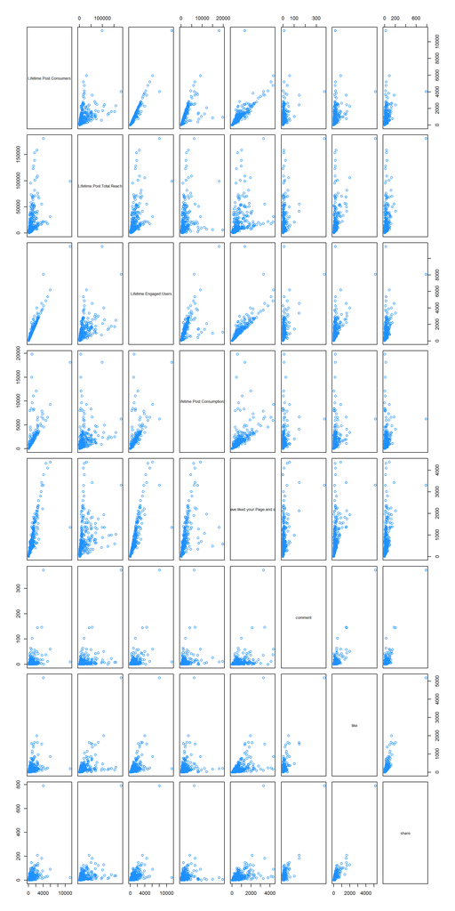

```r
pairs(fb_subset, col = "dodgerblue")
```

With the pairs plot, we can see it appears some relationships could be looked at, but quickly seeing the order of magnitude on the reponse variable, suggests we should also do a box-cox plot to determine if perhaps the response should be transformed.

#### 1.3 Box-Cox plots for MLR Models

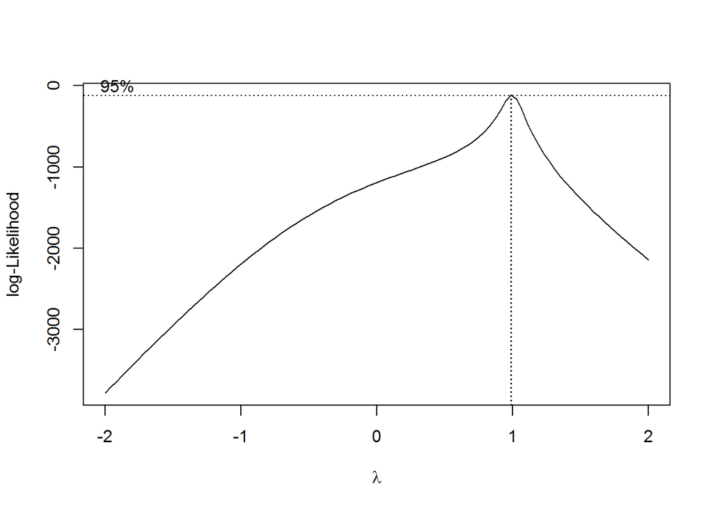

```r
boxcox(model_selected_RSS_Manual, plotit = TRUE)
```

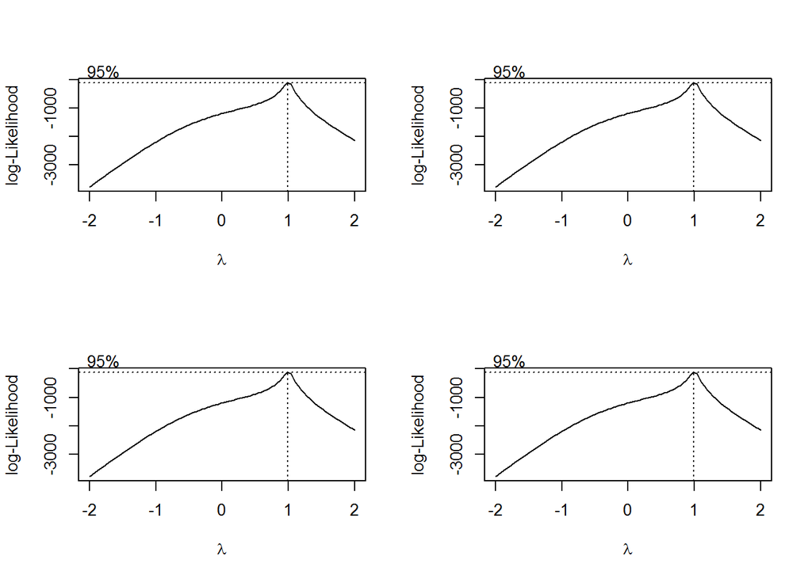

```r
par(mfrow = c(2,2))
boxcox(model_forward_aic, plotit = TRUE)
boxcox(model_back_aic, plotit = TRUE)
boxcox(model_forward_bic, plotit = TRUE)
boxcox(model_back_bic, plotit = TRUE)
```

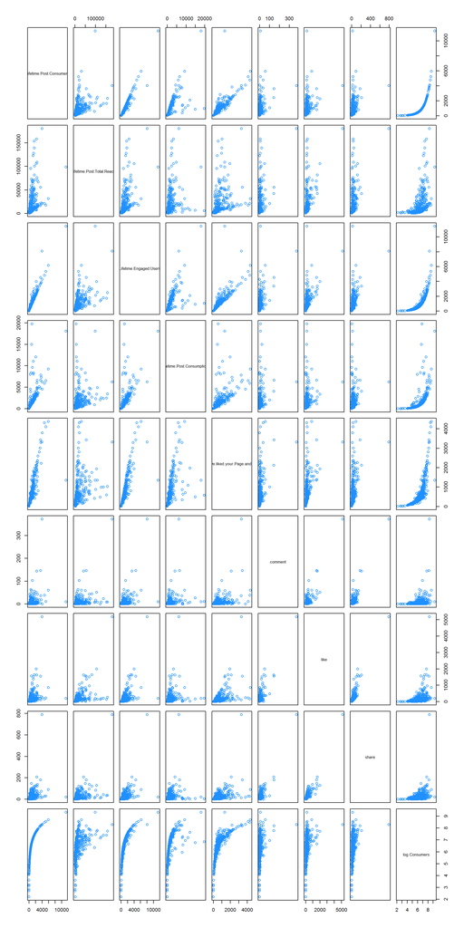

```r
fb_subset = subset(fb, select = c("Lifetime.Post.Consumers", "Lifetime.Post.Total.Reach", "Lifetime.Engaged.Users", "Lifetime.Post.Consumptions", "Lifetime.People.who.have.liked.your.Page.and.engaged.with.your.post", "comment", "like", "share"))

log.Consumers = log(fb_subset$Lifetime.Post.Consumers)

fb_withResponseTransform = cbind( fb_subset, log.Consumers)
pairs(fb_withResponseTransform, col = "dodgerblue")
```

Generically we will add + 1 to each predictor variable for log transformation to ensure the values are greater than 0 if the min val

```r
min(fb_withResponseTransform$Lifetime.Post.Total.Reach)
```

```
## [1] 238
```

```r
min(fb_withResponseTransform$Lifetime.Engaged.Users)
```

```
## [1] 9
```

```r
min(fb_withResponseTransform$Lifetime.Post.Consumptions)
```

```
## [1] 9
```

```r
min(fb_withResponseTransform$Lifetime.People.who.have.liked.your.Page.and.engaged.with.your.post)
```

```
## [1] 9
```

```r
min(fb_withResponseTransform$comment)
```

```
## [1] 0
```

```r
min(fb_withResponseTransform$like)
```

```
## [1] 0
```

```r
min(fb_withResponseTransform$share)
```

```
## [1] 0
```

The function below `transformationsPowers` automates checking for transformation. We are looking for a model for **explanation** so ensuring model assumptions are met is important in ensuring our model can explain well.

```r
transformationsPowers = function(predictor, response, dataset, responsevector, predictorvector){

  strQuad                      = paste("log(", response, ") ~ ", predictor , " + I(" , predictor, "^ 2) ")
  quad_model                   = lm(strQuad, data = dataset)
  quad_RMSE                    = sqrt(mean((responsevector - exp(fitted(quad_model))) ^ 2))
  quad_bp_p_value              = bptest(quad_model)$p.value
  quad_shapiro_p_value         = shapiro.test(resid(quad_model))$p.value

  strThird                     = paste("log(", response, ") ~ ", predictor , " + I(" , predictor, "^ 2)  + I(", predictor, "^3)")
  third_model                  = lm(strThird, data = dataset)
  third_RMSE                   = sqrt(mean((responsevector - exp(fitted(third_model))) ^ 2))
  third_bp_p_value             = bptest(third_model)$p.value
  third_shapiro_p_value        = shapiro.test(resid(third_model))$p.value

  predictor   = rep(predictor, 2)
  transform   = c("^2 obeying hierachy", "^3 obeying hierachy")
  bp          = c(quad_bp_p_value, third_bp_p_value)
  shapiro     = c(quad_shapiro_p_value, third_shapiro_p_value)
  RMSE        = c(quad_RMSE, third_RMSE)

  data.frame(predictor = predictor, transform = transform, bp = bp, shapiro = shapiro, RMSE = RMSE)

}

variables = colnames(fb_withResponseTransform)
predictor_variables = variables[which((variables != "Lifetime.Post.Consumers") & variables != "log.Consumers")]

length(predictor_variables)
```

```
## [1] 7
```

#### 1.5 Transformation Analysis

```r
result1 = transformationsPowers(predictor_variables[1], "Lifetime.Post.Consumers", fb_withResponseTransform, fb_withResponseTransform$Lifetime.Post.Consumers)
knitr::kable(result1, caption = "Transformation Review")
```

Transformation Review

| predictor | transform | bp | shapiro | RMSE |
| --- | --- | --- | --- | --- |
| Lifetime.Post.Total.Reach | ^2 obeying hierachy | 0.6870255 | 0 | 806.4718 |
| Lifetime.Post.Total.Reach | ^3 obeying hierachy | 0.9922775 | 0 | 841.1625 |

```r
result1 = transformationsPowers(predictor_variables[2], "Lifetime.Post.Consumers", fb_withResponseTransform, fb_withResponseTransform$Lifetime.Post.Consumers)
knitr::kable(result1, caption = "Transformation Review")
```

Transformation Review

| predictor | transform | bp | shapiro | RMSE |
| --- | --- | --- | --- | --- |
| Lifetime.Engaged.Users | ^2 obeying hierachy | 0 | 0 | 1014.5434 |
| Lifetime.Engaged.Users | ^3 obeying hierachy | 0 | 0 | 557.4647 |

```r
result1 = transformationsPowers(predictor_variables[3], "Lifetime.Post.Consumers", fb_withResponseTransform, fb_withResponseTransform$Lifetime.Post.Consumers)
knitr::kable(result1, caption = "Transformation Review")
```

Transformation Review

| predictor | transform | bp | shapiro | RMSE |
| --- | --- | --- | --- | --- |
| Lifetime.Post.Consumptions | ^2 obeying hierachy | 0 | 0 | 950.7600 |
| Lifetime.Post.Consumptions | ^3 obeying hierachy | 0 | 0 | 671.4429 |

```r
result1 = transformationsPowers(predictor_variables[4], "Lifetime.Post.Consumers", fb_withResponseTransform, fb_withResponseTransform$Lifetime.Post.Consumers)
knitr::kable(result1, caption = "Transformation Review")
```

Transformation Review

| predictor | transform | bp | shapiro | RMSE |
| --- | --- | --- | --- | --- |
| Lifetime.People.who.have.liked.your.Page.and.engaged.with.your.post | ^2 obeying hierachy | 0.0000414 | 0 | 703.3649 |
| Lifetime.People.who.have.liked.your.Page.and.engaged.with.your.post | ^3 obeying hierachy | 0.0001331 | 0 | 715.6237 |

```r
result1 = transformationsPowers(predictor_variables[5], "Lifetime.Post.Consumers", fb_withResponseTransform, fb_withResponseTransform$Lifetime.Post.Consumers)
knitr::kable(result1, caption = "Transformation Review")
```

Transformation Review

| predictor | transform | bp | shapiro | RMSE |
| --- | --- | --- | --- | --- |
| comment | ^2 obeying hierachy | 0.9160905 | 1e-07 | 920.7268 |
| comment | ^3 obeying hierachy | 0.6401742 | 1e-07 | 851.1077 |

```r
result1 = transformationsPowers(predictor_variables[6], "Lifetime.Post.Consumers", fb_withResponseTransform, fb_withResponseTransform$Lifetime.Post.Consumers)
knitr::kable(result1, caption = "Transformation Review")
```

Transformation Review

| predictor | transform | bp | shapiro | RMSE |
| --- | --- | --- | --- | --- |
| like | ^2 obeying hierachy | 0.4358813 | 3.0e-07 | 910.9140 |
| like | ^3 obeying hierachy | 0.0920669 | 1.5e-05 | 844.5598 |

```r
result1 = transformationsPowers(predictor_variables[7], "Lifetime.Post.Consumers", fb_withResponseTransform, fb_withResponseTransform$Lifetime.Post.Consumers)
knitr::kable(result1, caption = "Transformation Review")
```

Transformation Review

| predictor | transform | bp | shapiro | RMSE |
| --- | --- | --- | --- | --- |
| share | ^2 obeying hierachy | 0.0170792 | 2.0e-07 | 876.2189 |
| share | ^3 obeying hierachy | 0.0012753 | 4.5e-06 | 840.3944 |

```r
transformationsLog = function (response, predictors, dataset, responsevector){
  log_RMSE             = rep(0, length(predictors) )
  log_bp_p_value       = rep(0, length(predictors))
  log_shapiro_p_value  = rep(0, length(predictors))
  log_model_adjust_r2  = rep(0, length(predictors))

  quad_RMSE            = rep(0, length(predictors) )
  quad_bp_p_value      = rep(0, length(predictors) )
  quad_shapiro_p_value = rep(0, length(predictors) )
  quad_model_adjust_r2 = rep(0, length(predictors))

  third_RMSE            = rep(0, length(predictors) )
  third_bp_p_value      = rep(0, length(predictors) )
  third_shapiro_p_value = rep(0, length(predictors) )
  third_model_adjust_r2 = rep(0, length(predictors))

  log_strModel             = rep(0, length(predictors) )
  quad_strModel          = rep(0, length(predictors) )
  third_strModel         = rep(0, length(predictors) )


for (i in 1: length(predictors)){

  strLog = paste("log(", response, ") ~ log(", predictors[i] , ")")

  log_model = lm(strLog, data = dataset)

  log_RMSE[i]                     = sqrt(mean((responsevector - exp(fitted(log_model))) ^ 2))
  log_bp_p_value[i]               = bptest(log_model)$p.value
  log_shapiro_p_value[i]          = shapiro.test(resid(log_model))$p.value
  log_model_adjust_r2[i]          = summary(log_model)$adj.r.squared
  log_strModel[i]                 = strLog


    strQuad                      = paste("log(", response, ") ~ ", predictors[i] , " + I(" , predictors[i], "^ 2) ")

  quad_model                   = lm(strQuad, data = dataset)

  quad_RMSE[i]                    = sqrt(mean((responsevector - exp(fitted(quad_model))) ^ 2))
  quad_bp_p_value[i]              = bptest(quad_model)$p.value
  quad_shapiro_p_value[i]         = shapiro.test(resid(quad_model))$p.value
  quad_model_adjust_r2[i]          = summary(quad_model)$adj.r.squared
  quad_strModel[i]                 = strQuad

  strThird                     = paste("log(", response, ") ~ ", predictors[i] , " + I(" , predictors[i], "^ 2)  + I(", predictors[i], "^3)")
  third_model                  = lm(strThird, data = dataset)

  third_RMSE[i]                   = sqrt(mean((responsevector - exp(fitted(third_model))) ^ 2))
  third_bp_p_value[i]             = bptest(third_model)$p.value
  third_shapiro_p_value[i]        = shapiro.test(resid(third_model))$p.value
  third_model_adjust_r2[i]          = summary(third_model)$adj.r.squared
  third_strModel[i]                 = strThird

  transform   = c(rep("log", 7), rep("^2 with hiearchy", 7), rep("^3 with hierarchy", 7))
  strModel    = c(log_strModel, quad_strModel, third_strModel)
  bp          = c(log_bp_p_value,      quad_bp_p_value,      third_bp_p_value)
  shapiro     = c(log_shapiro_p_value, quad_shapiro_p_value, third_shapiro_p_value)
  RMSE        = c(log_RMSE,            quad_RMSE,            third_RMSE)
  adj_r_squard = c(log_model_adjust_r2, quad_model_adjust_r2, third_model_adjust_r2)

}

  data.frame( model = strModel, predictor = rep(predictors, 3), bp = bp, shapiro = shapiro, RMSE = RMSE, adj_r_squard = adj_r_squard )

}
```

In order to explore log transformations on predictor variables, in the case when the range is from 0 to some value, we will add 1 to the predictor variables given their min value is at 0.

```r
fb_withResponseTransformForLog = fb_withResponseTransform
fb_withResponseTransformForLog$like = fb_withResponseTransformForLog$like + 1
fb_withResponseTransformForLog$share = fb_withResponseTransformForLog$share + 1
fb_withResponseTransformForLog$comment = fb_withResponseTransformForLog$comment + 1

(predictor_variables)
```

```
## [1] "Lifetime.Post.Total.Reach"
## [2] "Lifetime.Engaged.Users"
## [3] "Lifetime.Post.Consumptions"
## [4] "Lifetime.People.who.have.liked.your.Page.and.engaged.with.your.post"
## [5] "comment"
## [6] "like"
## [7] "share"
```

```r
length(predictor_variables)
```

```
## [1] 7
```

```r
result1 = transformationsLog("Lifetime.Post.Consumers", predictor_variables, fb_withResponseTransformForLog, fb_withResponseTransformForLog$Lifetime.Post.Consumers )

knitr::kable(result1, caption = "Transformation Review with transformed predictors added 1")
```

Transformation Review with transformed predictors added 1

| model | predictor | bp | shapiro | RMSE | adj_r_squard |
| --- | --- | --- | --- | --- | --- |
| log( Lifetime.Post.Consumers ) ~ log( Lifetime.Post.Total.Reach ) | Lifetime.Post.Total.Reach | 0.9358177 | 0.0000000 | 761.6745 | 0.4220192 |
| log( Lifetime.Post.Consumers ) ~ log( Lifetime.Engaged.Users ) | Lifetime.Engaged.Users | 0.0778719 | 0.0000000 | 221.9908 | 0.9673523 |
| log( Lifetime.Post.Consumers ) ~ log( Lifetime.Post.Consumptions ) | Lifetime.Post.Consumptions | 0.0000000 | 0.0000000 | 620.5757 | 0.8532396 |
| log( Lifetime.Post.Consumers ) ~ log( Lifetime.People.who.have.liked.your.Page.and.engaged.with.your.post ) | Lifetime.People.who.have.liked.your.Page.and.engaged.with.your.post | 0.0823193 | 0.0000000 | 524.1905 | 0.8840947 |
| log( Lifetime.Post.Consumers ) ~ log( comment ) | comment | 0.0069794 | 0.0000079 | 837.7217 | 0.1960139 |
| log( Lifetime.Post.Consumers ) ~ log( like ) | like | 0.0023929 | 0.7101605 | 824.7945 | 0.3537671 |
| log( Lifetime.Post.Consumers ) ~ log( share ) | share | 0.0000023 | 0.0267167 | 835.9544 | 0.2881216 |
| log( Lifetime.Post.Consumers ) ~ Lifetime.Post.Total.Reach + I( Lifetime.Post.Total.Reach ^ 2) | Lifetime.Post.Total.Reach | 0.6870255 | 0.0000000 | 806.4718 | 0.2798718 |
| log( Lifetime.Post.Consumers ) ~ Lifetime.Engaged.Users + I( Lifetime.Engaged.Users ^ 2) | Lifetime.Engaged.Users | 0.0000000 | 0.0000000 | 1014.5434 | 0.7505581 |
| log( Lifetime.Post.Consumers ) ~ Lifetime.Post.Consumptions + I( Lifetime.Post.Consumptions ^ 2) | Lifetime.Post.Consumptions | 0.0000000 | 0.0000000 | 950.7600 | 0.5716897 |
| log( Lifetime.Post.Consumers ) ~ Lifetime.People.who.have.liked.your.Page.and.engaged.with.your.post + I( Lifetime.People.who.have.liked.your.Page.and.engaged.with.your.post ^ 2) | Lifetime.People.who.have.liked.your.Page.and.engaged.with.your.post | 0.0000414 | 0.0000000 | 703.3649 | 0.6956547 |
| log( Lifetime.Post.Consumers ) ~ comment + I( comment ^ 2) | comment | 0.9160905 | 0.0000001 | 920.7268 | 0.1242307 |
| log( Lifetime.Post.Consumers ) ~ like + I( like ^ 2) | like | 0.4358813 | 0.0000003 | 910.9140 | 0.1735935 |
| log( Lifetime.Post.Consumers ) ~ share + I( share ^ 2) | share | 0.0170792 | 0.0000002 | 876.2189 | 0.2115213 |
| log( Lifetime.Post.Consumers ) ~ Lifetime.Post.Total.Reach + I( Lifetime.Post.Total.Reach ^ 2) + I( Lifetime.Post.Total.Reach ^3) | Lifetime.Post.Total.Reach | 0.9922775 | 0.0000000 | 841.1625 | 0.3362557 |
| log( Lifetime.Post.Consumers ) ~ Lifetime.Engaged.Users + I( Lifetime.Engaged.Users ^ 2) + I( Lifetime.Engaged.Users ^3) | Lifetime.Engaged.Users | 0.0000000 | 0.0000000 | 557.4647 | 0.8434946 |
| log( Lifetime.Post.Consumers ) ~ Lifetime.Post.Consumptions + I( Lifetime.Post.Consumptions ^ 2) + I( Lifetime.Post.Consumptions ^3) | Lifetime.Post.Consumptions | 0.0000000 | 0.0000000 | 671.4429 | 0.7276299 |
| log( Lifetime.Post.Consumers ) ~ Lifetime.People.who.have.liked.your.Page.and.engaged.with.your.post + I( Lifetime.People.who.have.liked.your.Page.and.engaged.with.your.post ^ 2) + I( Lifetime.People.… | Lifetime.People.who.have.liked.your.Page.and.engaged.with.your.post | 0.0001331 | 0.0000000 | 715.6237 | 0.7973120 |
| log( Lifetime.Post.Consumers ) ~ comment + I( comment ^ 2) + I( comment ^3) | comment | 0.6401742 | 0.0000001 | 851.1077 | 0.1484934 |
| log( Lifetime.Post.Consumers ) ~ like + I( like ^ 2) + I( like ^3) | like | 0.0920669 | 0.0000150 | 844.5598 | 0.2305060 |
| log( Lifetime.Post.Consumers ) ~ share + I( share ^ 2) + I( share ^3) | share | 0.0012753 | 0.0000045 | 840.3944 | 0.2345404 |

```r
##function
diagnostics = function(model, pcol= 2, lcol = 1, alpha = 0.05, plotit = TRUE, testit = TRUE){
  if (plotit == TRUE){
    par(mfrow = c(1, 2))
    plot(fitted(model), resid(model), col = pcol, pch = 20,
         xlab = "Fitted", ylab = "Residuals", main = "Fitted vs Residuals")
    abline(h = 0, col = lcol, lwd = 2)
    qqnorm(resid(model), main = "Normal Q-Q Plot", col = pcol)
    qqline(resid(model), col = lcol, lwd = 2)
  }
  if (testit == TRUE){
    shapiro_p_value = shapiro.test(resid(model))$p.value
    bp_p_value      = bptest(model)$p.value
    bp_decision      = ifelse(bp_p_value < alpha, "Reject Equal Variance - Bad", "Fail to Equal Variance-Good")
    shapiro_decision = ifelse(shapiro_p_value < alpha, "Reject Normality - Bad", "Fail to Reject Normality- Good")

    return_val = list(shapiro_p_value = shapiro_p_value, bp_p_value = bp_p_value, bp_decision = bp_decision, shapiro_decision = shapiro_decision)
    return_val
  }
}
```

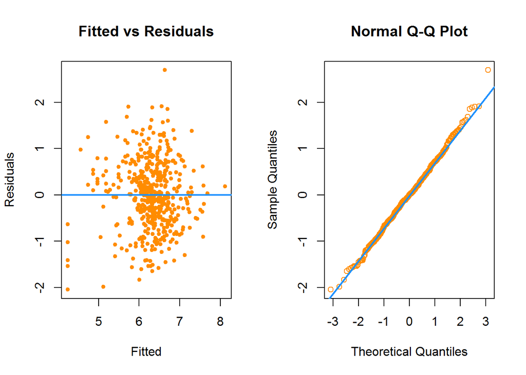

```
## $shapiro_p_value
## [1] 0.7101605
##
## $bp_p_value
##          BP
## 0.002392909
##
## $bp_decision
##                            BP
## "Reject Equal Variance - Bad"
##
## $shapiro_decision
## [1] "Fail to Reject Normality- Good"
```

```r
#dataset to use for analysis
m1 = lm(log(Lifetime.Post.Consumers) ~ log(like), data = fb_withResponseTransformForLog,
        testit = TRUE, pcol = "darkorange", lcol = "dodgerblue", plotit = TRUE)

m2 = lm(log(Lifetime.Post.Consumers) ~ log(like) + like, data = fb_withResponseTransformForLog,
        testit = TRUE, pcol = "darkorange", lcol = "dodgerblue", plotit = TRUE)

m3 = lm(log(Lifetime.Post.Consumers) ~ log(share), data = fb_withResponseTransformForLog,
        testit = TRUE, pcol = "darkorange", lcol = "dodgerblue", plotit = TRUE)

m4 = lm(log(Lifetime.Post.Consumers) ~ log(share) + share, data = fb_withResponseTransformForLog,
        testit = TRUE, pcol = "darkorange", lcol = "dodgerblue", plotit = TRUE)

m5 =  lm(log(Lifetime.Post.Consumers) ~ like + log(like) + log(share) + share, data = fb_withResponseTransformForLog,
                  testit = TRUE, pcol = "darkorange", lcol = "dodgerblue", plotit = TRUE)

diagnostics(m1, testit = TRUE, pcol = "darkorange", lcol = "dodgerblue", plotit = TRUE)
```

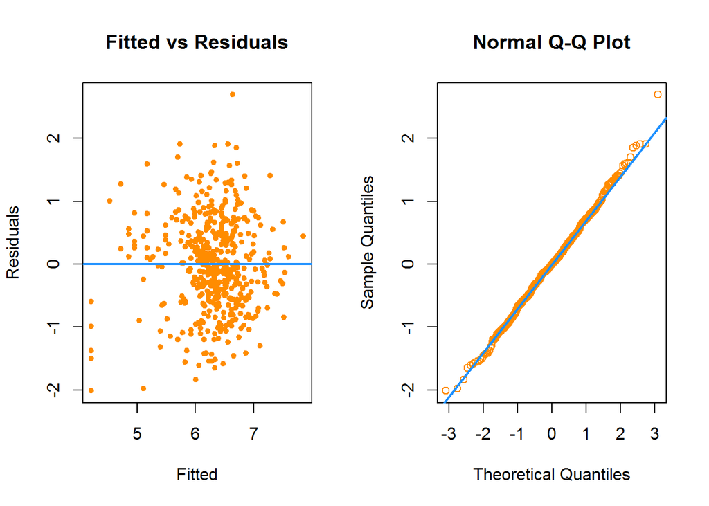

```
## $shapiro_p_value
## [1] 0.730726
##
## $bp_p_value
##        BP
## 0.0116641
##
## $bp_decision
##                            BP
## "Reject Equal Variance - Bad"
##
## $shapiro_decision
## [1] "Fail to Reject Normality- Good"
```

```r
diagnostics(m2, testit = TRUE, pcol = "darkorange", lcol = "dodgerblue", plotit = TRUE)
```

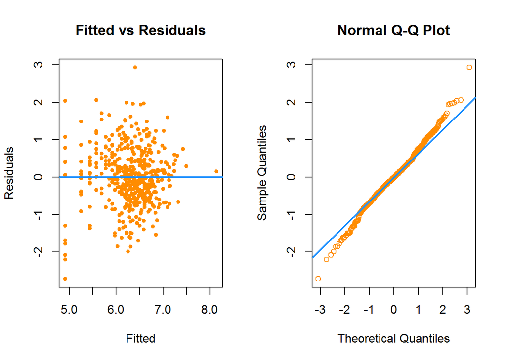

```
## $shapiro_p_value
## [1] 0.02671666
##
## $bp_p_value
##           BP
## 2.328422e-06
##
## $bp_decision
##                            BP
## "Reject Equal Variance - Bad"
##
## $shapiro_decision
## [1] "Reject Normality - Bad"
```

```r
diagnostics(m3, testit = TRUE, pcol = "darkorange", lcol = "dodgerblue", plotit = TRUE)
```

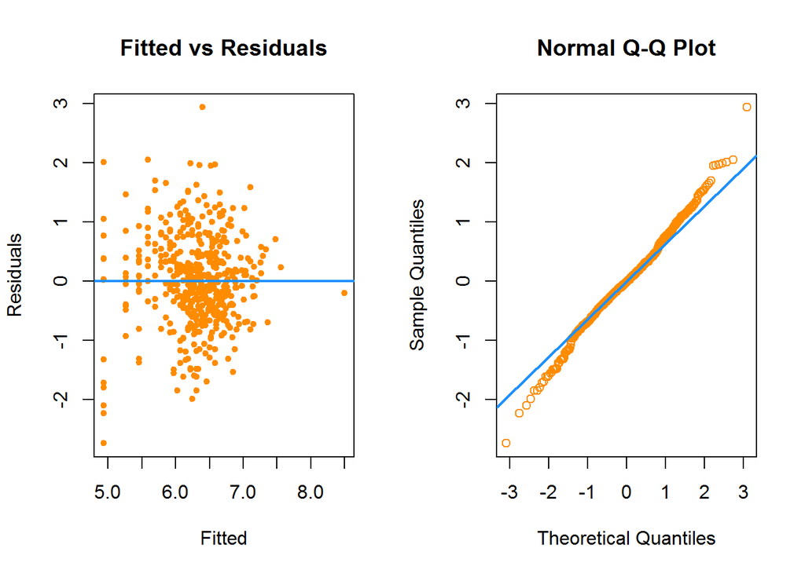

```
## $shapiro_p_value
## [1] 0.01949664
##
## $bp_p_value
##           BP
## 9.015139e-06
##
## $bp_decision
##                            BP
## "Reject Equal Variance - Bad"
##
## $shapiro_decision
## [1] "Reject Normality - Bad"
```

```r
diagnostics(m4, testit = TRUE, pcol = "darkorange", lcol = "dodgerblue", plotit = TRUE)
```

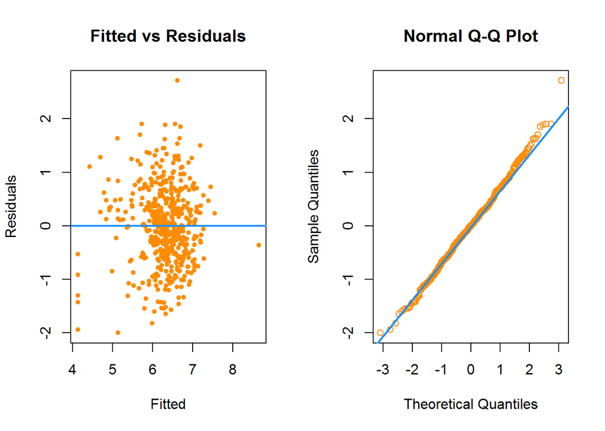

```
## $shapiro_p_value
## [1] 0.6326205
##
## $bp_p_value
##         BP
## 0.04417037
##
## $bp_decision
##                            BP
## "Reject Equal Variance - Bad"
##
## $shapiro_decision
## [1] "Fail to Reject Normality- Good"
```

```r
diagnostics(m5, testit = TRUE, pcol = "darkorange", lcol = "dodgerblue", plotit = TRUE)
```

#### Factor Variables

To further investigate creation of a model for explanation, recall that the RSS Manual model included the variable `Post.Month` so we will further investigate if putting this variable into the model will be helpful.

```r
fb_subset = subset(fb, select = c("Lifetime.Post.Consumers", "Lifetime.Post.Total.Reach", "Lifetime.Engaged.Users", "Lifetime.Post.Consumptions", "Lifetime.People.who.have.liked.your.Page.and.engaged.with.your.post", "comment", "like", "share", "Post.Month", "Post.Weekday", "Post.Hour", "Paid"))

fb_subset$like = fb_subset$like + 1
fb_subset$share = fb_subset$share + 1
fb_subset$comment = fb_subset$comment + 1


current_best_model = lm(log(Lifetime.Post.Consumers) ~ like + log(like) + log(share) + share, data = fb_subset)

model_month = lm(log(Lifetime.Post.Consumers) ~ like + log(like) + log(share) + share + Post.Month, data = fb_subset)

summary(model_month)
```

```
##
## Call:
## lm(formula = log(Lifetime.Post.Consumers) ~ like + log(like) +
##     log(share) + share + Post.Month, data = fb_subset)
##
## Residuals:
##      Min       1Q   Median       3Q      Max
## -2.20586 -0.34726 -0.08344  0.29041  2.43111
##
## Coefficients:
##                Estimate Std. Error t value Pr(>|t|)
## (Intercept)   4.3689476  0.1933205  22.600  < 2e-16 ***
## like         -0.0006223  0.0002671  -2.330 0.020245 *
## log(like)     0.5661378  0.0672566   8.418 4.48e-16 ***
## log(share)   -0.0980479  0.0812034  -1.207 0.227860
## share         0.0043930  0.0020379   2.156 0.031609 *
## Post.Month2   0.2832665  0.1802677   1.571 0.116758
## Post.Month3  -0.1292797  0.1759570  -0.735 0.462867
## Post.Month4  -0.2523166  0.1591089  -1.586 0.113442
## Post.Month5  -0.4351250  0.1681410  -2.588 0.009951 **
## Post.Month6   0.0235123  0.1624648   0.145 0.884991
## Post.Month7  -0.2830379  0.1598611  -1.771 0.077276 .
## Post.Month8  -0.4365651  0.1750846  -2.493 0.012987 *
## Post.Month9  -0.6353904  0.1709538  -3.717 0.000226 ***
## Post.Month10 -0.3099598  0.1575788  -1.967 0.049758 *
## Post.Month11 -1.0586685  0.1629947  -6.495 2.08e-10 ***
## Post.Month12 -0.8503634  0.1604963  -5.298 1.79e-07 ***
## ---
## Signif. codes:  0 '***' 0.001 '**' 0.01 '*' 0.05 '.' 0.1 ' ' 1
##
## Residual standard error: 0.6351 on 479 degrees of freedom
## Multiple R-squared:  0.5142, Adjusted R-squared:  0.499
## F-statistic: 33.81 on 15 and 479 DF,  p-value: < 2.2e-16
```

```r
anova(current_best_model, model_month)
```

```
## Analysis of Variance Table
##
## Model 1: log(Lifetime.Post.Consumers) ~ like + log(like) + log(share) +
##     share
## Model 2: log(Lifetime.Post.Consumers) ~ like + log(like) + log(share) +
##     share + Post.Month
##   Res.Df    RSS Df Sum of Sq      F    Pr(>F)
## 1    490 253.49
## 2    479 193.22 11     60.27 13.583 < 2.2e-16 ***
## ---
## Signif. codes:  0 '***' 0.001 '**' 0.01 '*' 0.05 '.' 0.1 ' ' 1
```

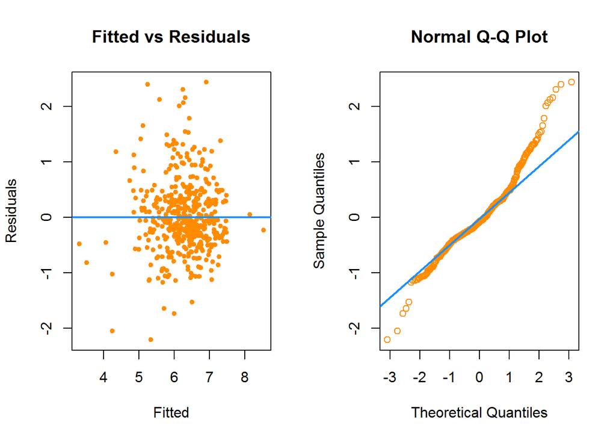

```
## $shapiro_p_value
## [1] 2.572213e-11
##
## $bp_p_value
##           BP
## 4.439209e-07
##
## $bp_decision
##                            BP
## "Reject Equal Variance - Bad"
##
## $shapiro_decision
## [1] "Reject Normality - Bad"
```

```r
diagnostics(model_month, testit = TRUE, pcol = "darkorange", lcol = "dodgerblue", plotit = TRUE)
```

```r
model_int_forward_aic = step(current_best_model,
                         log(Lifetime.Post.Consumers) ~ like + log(like) + log(share) + share + Post.Month,
                         direction = "forward", trace = 0)

summary(model_int_forward_aic)
```

```
##
## Call:
## lm(formula = log(Lifetime.Post.Consumers) ~ like + log(like) +
##     log(share) + share + Post.Month, data = fb_subset)
##
## Residuals:
##      Min       1Q   Median       3Q      Max
## -2.20586 -0.34726 -0.08344  0.29041  2.43111
##
## Coefficients:
##                Estimate Std. Error t value Pr(>|t|)
## (Intercept)   4.3689476  0.1933205  22.600  < 2e-16 ***
## like         -0.0006223  0.0002671  -2.330 0.020245 *
## log(like)     0.5661378  0.0672566   8.418 4.48e-16 ***
## log(share)   -0.0980479  0.0812034  -1.207 0.227860
## share         0.0043930  0.0020379   2.156 0.031609 *
## Post.Month2   0.2832665  0.1802677   1.571 0.116758
## Post.Month3  -0.1292797  0.1759570  -0.735 0.462867
## Post.Month4  -0.2523166  0.1591089  -1.586 0.113442
## Post.Month5  -0.4351250  0.1681410  -2.588 0.009951 **
## Post.Month6   0.0235123  0.1624648   0.145 0.884991
## Post.Month7  -0.2830379  0.1598611  -1.771 0.077276 .
## Post.Month8  -0.4365651  0.1750846  -2.493 0.012987 *
## Post.Month9  -0.6353904  0.1709538  -3.717 0.000226 ***
## Post.Month10 -0.3099598  0.1575788  -1.967 0.049758 *
## Post.Month11 -1.0586685  0.1629947  -6.495 2.08e-10 ***
## Post.Month12 -0.8503634  0.1604963  -5.298 1.79e-07 ***
## ---
## Signif. codes:  0 '***' 0.001 '**' 0.01 '*' 0.05 '.' 0.1 ' ' 1
##
## Residual standard error: 0.6351 on 479 degrees of freedom
## Multiple R-squared:  0.5142, Adjusted R-squared:  0.499
## F-statistic: 33.81 on 15 and 479 DF,  p-value: < 2.2e-16
```

The variables that seem to be the most significant are `Post.Month12` and `Post.Month11`. We will explore creating dummy variables to look specifically at these 2 months to determine if they could be included in the model.

```r
PostMonth12 = 1 * as.numeric(fb_subset$Post.Month == "12")
PostMonth11 = 1 * as.numeric(fb_subset$Post.Month == "11")

length(PostMonth12)
```

```
## [1] 495
```

```r
length(PostMonth11 )
```

```
## [1] 495
```

```r
nrow(fb_subset)
```

```
## [1] 495
```

```r
fb_data = cbind( fb_subset, PostMonth11, PostMonth12)

head(fb_data)
```

```
##   Lifetime.Post.Consumers Lifetime.Post.Total.Reach Lifetime.Engaged.Users
## 1                     109                      2752                    178
## 2                    1361                     10460                   1457
## 3                     113                      2413                    177
## 4                     790                     50128                   2211
## 5                     410                      7244                    671
## 6                    1073                     10472                   1191
##   Lifetime.Post.Consumptions
## 1                        159
## 2                       1674
## 3                        154
## 4                       1119
## 5                        580
## 6                       1389
##   Lifetime.People.who.have.liked.your.Page.and.engaged.with.your.post
```

[output cut: 20 more lines]

```r
#nrow(fb_data)
#colnames(fb_data)


model_month11 = lm(log(Lifetime.Post.Consumers) ~ like + log(like) + log(share) + share
                 + PostMonth11, data = fb_data)

current_best_model = lm(log(Lifetime.Post.Consumers) ~ like + log(like) + log(share) + share, data = fb_subset)
anova(current_best_model, model_month11)
```

```
## Analysis of Variance Table
##
## Model 1: log(Lifetime.Post.Consumers) ~ like + log(like) + log(share) +
##     share
## Model 2: log(Lifetime.Post.Consumers) ~ like + log(like) + log(share) +
##     share + PostMonth11
##   Res.Df    RSS Df Sum of Sq      F    Pr(>F)
## 1    490 253.49
## 2    489 230.38  1    23.102 49.034 8.354e-12 ***
## ---
## Signif. codes:  0 '***' 0.001 '**' 0.01 '*' 0.05 '.' 0.1 ' ' 1
```

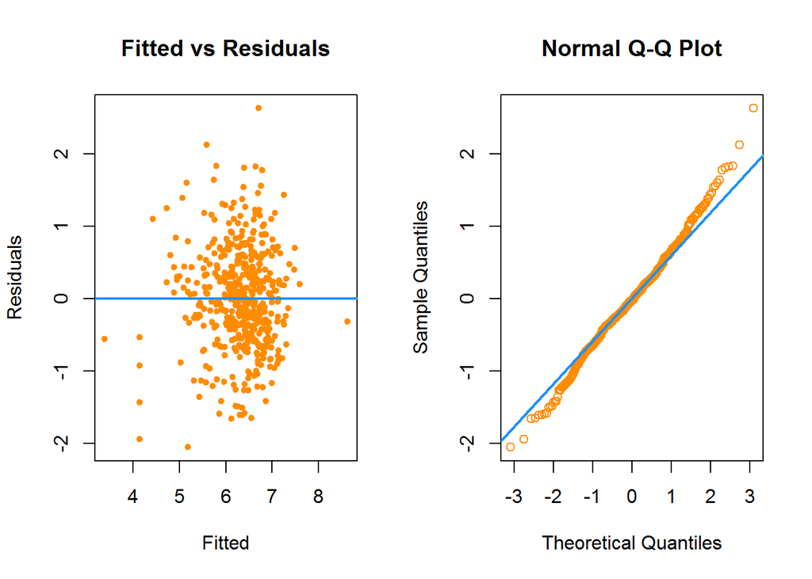

```
## $shapiro_p_value
## [1] 0.07281075
##
## $bp_p_value
##         BP
## 0.05983206
##
## $bp_decision
##                            BP
## "Fail to Equal Variance-Good"
##
## $shapiro_decision
## [1] "Fail to Reject Normality- Good"
```

```r
diagnostics(model_month11, testit = TRUE, pcol = "darkorange", lcol = "dodgerblue", plotit = TRUE)
```

```r
vif(model_month11)
```

```
##        like   log(like)  log(share)       share PostMonth11
##    8.973665    7.240590    7.299858    9.039998    1.005191
```

Including when the `Post.Month` == 11 to our model as a dummy variable has improved our ability to fufill the assumptions of the model. According to the anova test, this is significant. Our VIF has increased between the variables, so we will need further exploration to determine which is the best model.

```r
model_month12 = lm(log(Lifetime.Post.Consumers) ~ like + log(like) + log(share) + share
                 + PostMonth12, data = fb_data)

anova(current_best_model, model_month12)
```

```
## Analysis of Variance Table
##
## Model 1: log(Lifetime.Post.Consumers) ~ like + log(like) + log(share) +
##     share
## Model 2: log(Lifetime.Post.Consumers) ~ like + log(like) + log(share) +
##     share + PostMonth12
##   Res.Df    RSS Df Sum of Sq      F    Pr(>F)
## 1    490 253.49
## 2    489 240.91  1    12.574 25.522 6.188e-07 ***
## ---
## Signif. codes:  0 '***' 0.001 '**' 0.01 '*' 0.05 '.' 0.1 ' ' 1
```

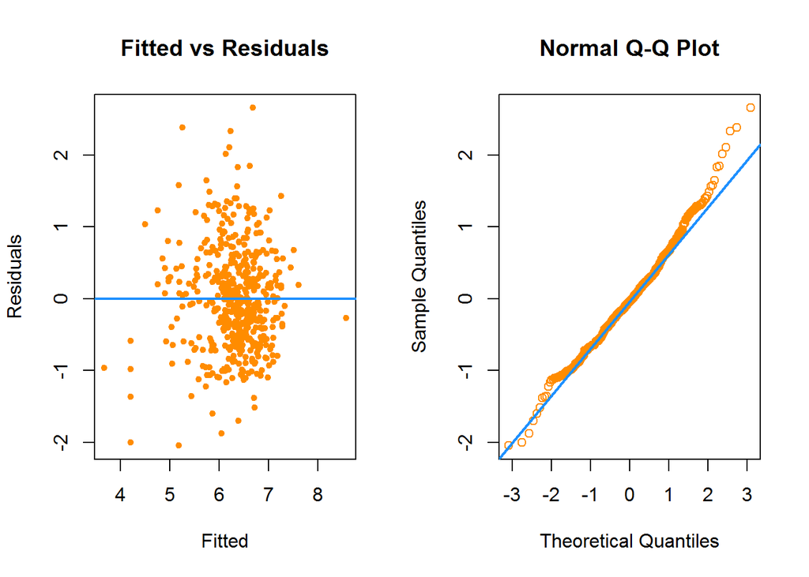

```
## $shapiro_p_value
## [1] 0.0004846325
##
## $bp_p_value
##           BP
## 1.907707e-05
##
## $bp_decision
##                            BP
## "Reject Equal Variance - Bad"
##
## $shapiro_decision
## [1] "Reject Normality - Bad"
```

```r
diagnostics(model_month12, testit = TRUE, pcol = "darkorange", lcol = "dodgerblue", plotit = TRUE)
```

As demonstrated above, including `Post.Month` == 12 to our model did not improve our ability to meeting the assumptions of the model, so while it is significant, we would like to consider models that will do a good job of explaining.

Next we will look at including iteraction terms with this variable to determine if that will also improve our model.

```r
fb_data$PostMonth11 = as.factor(fb_data$PostMonth11)

model_month11 = lm(log(Lifetime.Post.Consumers) ~ (like + log(like) + log(share) + share)
                 + PostMonth11, data = fb_data)

model_month11_int = lm(log(Lifetime.Post.Consumers) ~ (like + log(like) + log(share) + share)
                 * PostMonth11, data = fb_data)

summary(model_month11_int)
```

```
##
## Call:
## lm(formula = log(Lifetime.Post.Consumers) ~ (like + log(like) +
##     log(share) + share) * PostMonth11, data = fb_data)
##
## Residuals:
##      Min       1Q   Median       3Q      Max
## -2.05229 -0.39621 -0.01949  0.40737  2.64073
##
## Coefficients:
##                           Estimate Std. Error t value Pr(>|t|)
## (Intercept)              4.1743915  0.1574072  26.520  < 2e-16 ***
## like                    -0.0007431  0.0002900  -2.563   0.0107 *
## log(like)                0.5206977  0.0731713   7.116 4.01e-12 ***
## log(share)              -0.0661853  0.0862210  -0.768   0.4431
## share                    0.0053654  0.0022051   2.433   0.0153 *
## PostMonth111            -0.9538815  0.6391401  -1.492   0.1362
## like:PostMonth111       -0.0002139  0.0021342  -0.100   0.9202
## log(like):PostMonth111   0.3073228  0.3400721   0.904   0.3666
## log(share):PostMonth111 -0.5051270  0.5626410  -0.898   0.3697
## share:PostMonth111       0.0110512  0.0193409   0.571   0.5680
## ---
## Signif. codes:  0 '***' 0.001 '**' 0.01 '*' 0.05 '.' 0.1 ' ' 1
##
## Residual standard error: 0.6879 on 485 degrees of freedom
## Multiple R-squared:  0.423,  Adjusted R-squared:  0.4123
## F-statistic: 39.51 on 9 and 485 DF,  p-value: < 2.2e-16
```

```r
anova(model_month11, model_month11_int)
```

```
## Analysis of Variance Table
##
## Model 1: log(Lifetime.Post.Consumers) ~ (like + log(like) + log(share) +
##     share) + PostMonth11
## Model 2: log(Lifetime.Post.Consumers) ~ (like + log(like) + log(share) +
##     share) * PostMonth11
##   Res.Df    RSS Df Sum of Sq      F Pr(>F)
## 1    489 230.38
## 2    485 229.50  4   0.88731 0.4688 0.7587
```

Due to the anova F-Test, we will keep the initial model without interaction terms.

#### Influence, Leverages & Outliers

Next we will identify points of influence.

```r
model_month11 = lm(log(Lifetime.Post.Consumers) ~ (like + share + log(like) + log(share) )
                 + PostMonth11, data = fb_data)

which.max(hatvalues(model_month11))
```

```
## 245
## 241
```

```r
fb_data[which.max(hatvalues(model_month11)),]
```

```
##     Lifetime.Post.Consumers Lifetime.Post.Total.Reach
## 245                    4010                    180480
##     Lifetime.Engaged.Users Lifetime.Post.Consumptions
## 245                   8072                       6242
##     Lifetime.People.who.have.liked.your.Page.and.engaged.with.your.post
## 245                                                                3316
##     comment like share Post.Month Post.Weekday Post.Hour Paid PostMonth11
## 245     373 5173   791          7            3         5    1           0
##     PostMonth12
## 245           0
```

```r
#how many points have a large leverage
sum(hatvalues(model_month11) > 2 * mean(hatvalues(model_month11)))
```

```
## [1] 55
```

```r
rstandard(model_month11)[abs(rstandard(model_month11)) > 2]
```

```
##         1         3         8        11        12        13        14
## -2.345106 -2.165472 -2.086786  2.274035 -2.197469 -2.354435 -2.419971
##        19        20        22        24        28        39        43
## -2.425725 -2.069918 -2.140519 -2.183882 -2.317131  2.592843  2.687689
##        47        80        81       132       143       173       226
##  2.126268  2.057821  3.135021  2.350770  2.109240  2.664656  2.254254
##       276       315       431       439       442       447       448
##  2.645038  2.399948 -3.029469 -2.330923 -2.903253  3.842483  2.014331
```

**Need to examine what the model looks like especially the Fitted vs Residula plots with the outliers taken out. Does that improve our model?**

#### Validation

RMSE - Confidence Intervals - LOOCV - Adjusted R^2 -

```r
set.seed(42)
train_index = sample(1:nrow(fb_data), 250)
train = fb_data[train_index ,]
test  = fb_data[-train_index ,]

nrow(train)
```

```
## [1] 250
```

```r
nrow(test)
```

```
## [1] 245
```

```r
head(train$leverages)
```

[output not shown]

```r
RMSE= function(model, name, predictors) {

  RMSE_train   = sqrt( mean(  resid(model) ^ 2  ))
  RMSE_test  = sqrt(mean( (test$Lifetime.Post.Consumers - exp(predict(model, newdata = test)))^2 ))

  RMSE_train2 = sqrt(mean((train$Lifetime.Post.Consumers - exp(fitted(model))) ^ 2))




  values = c(
    Name       = name,
    RMSE_train = RMSE_train,
    RMSE_train2 = RMSE_train2,
    RMSE_test  = RMSE_test)
}

model_1 = lm(log(Lifetime.Post.Consumers) ~ like + log(like) + log(share) + share , data = train)
model_2 = lm(log(Lifetime.Post.Consumers) ~ like + log(like), data = train)
model_3 = lm(log(Lifetime.Post.Consumers) ~ log(share) + share, data = train)
model_4 = lm(log(Lifetime.Post.Consumers) ~ log(like) + log(share), data = train)



result = rbind( RMSE(model_1, "Model 1", "tax"),
                RMSE(model_2, "Model 2", "zn + nox + rm + dis + rad + tax + ptratio + black + lstat"),
                RMSE(model_3, "Model 3", "zn + nox + rm  + dis  + tax + ptratio + black + lstat"),
                RMSE(model_4, "Model 4", "zn + nox + rm  + dis + black  + ptratio + lstat")
                )


kable(result, format = "markdown", padding = 3)
```

| Name | RMSE_train | RMSE_train2 | RMSE_test |
| --- | --- | --- | --- |
| Model 1 | 0.710517942876329 | 647.492651104514 | 962.213345538409 |
| Model 2 | 0.711057076514091 | 649.408433606083 | 986.477518826875 |
| Model 3 | 0.756749706286619 | 668.176579805599 | 977.207519180009 |
| Model 4 | 0.712875336980118 | 649.803834883831 | 962.435000099879 |

```r
calc_diags = function(model) {
  loocv_rmse        = sqrt(mean((resid(model) / (1 - hatvalues(model))) ^ 2))
  adjusted_r2       = summary(model)$adj.r.squared
  bptest            = bptest(model)$p.value
  shapiro_p_value   = shapiro.test(resid(model))$p.value

  data.frame(loocv_rmse = loocv_rmse, adjusted_r2 = adjusted_r2, bptest = bptest, shapiro_p_value = shapiro_p_value)
}


model_1 = lm(log(Lifetime.Post.Consumers) ~ like + share + log(like) + log(share) + PostMonth11 , data = fb_data)
model_2 = lm(log(Lifetime.Post.Consumers) ~ like + log(like), data = fb_data)
model_3 = lm(log(Lifetime.Post.Consumers) ~ log(share) + share, data = fb_data)
model_4 = lm(log(Lifetime.Post.Consumers) ~ log(like) + log(share), data = fb_data)

calc_diags(model_1)
```

```
##    loocv_rmse adjusted_r2     bptest shapiro_p_value
## BP  0.6938263   0.4148794 0.05983206      0.07281075
```

```r
calc_diags(model_2)
```

```
##    loocv_rmse adjusted_r2    bptest shapiro_p_value
## BP  0.7252621   0.3527573 0.0116641        0.730726
```

```r
calc_diags(model_3)
```

```
##    loocv_rmse adjusted_r2       bptest shapiro_p_value
## BP  0.7611364   0.2870789 9.015139e-06      0.01949664
```

```r
calc_diags(model_4)
```

```
##    loocv_rmse adjusted_r2      bptest shapiro_p_value
## BP  0.7243296    0.353312 0.006235283        0.691039
```